# 02. Quality Of Data - digging the Event Log

Roberto Gatta

14/01/2022

# 1 Introduction

**QOD** is a class aimed at checking and exploring the Quality of the Data in the Event Log. This class provides methods for visual and numerical inspection to also support a first Decriptive Statistics. It works loading an object obtained with the *dataLoader::getData()* method: this means that an Event Log must be previously loaded via a *dataLoader* object.

## 1.1 Data Loading

Let’s consider the following CSV, containing the Event Log we might want to load:

| ID | Event | Date | Sex |
| --- | --- | --- | --- |
| 1 | Medical Visit | 2001-01-04 | M |
| 1 | Imaging | 2001-01-11 | M |
| 1 | Imaging | 2001-01-16 | M |
| 1 | Imaging | 2001-01-19 | M |
| 1 | Medical Visit | 2001-01-21 | M |
| 1 | Imaging | 2001-01-31 | M |
| 1 | Biopsy | 2001-02-08 | M |
| 1 | partial resection | 2001-02-12 | M |
| 1 | death | 2001-02-17 | M |
| 2 | Imaging | 2001-01-09 | M |
| 2 | Imaging | 2001-01-14 | M |
| 2 | Imaging | 2001-01-19 | M |
| 2 | Imaging | 2001-01-27 | M |
| 2 | Medical Visit | 2001-02-05 | M |
| 2 | Medical Visit | 2001-02-07 | M |

On first we have to load the Event Log with a *dataLoder* object:

```r
objDL <- dataLoader(verbose.mode = FALSE)
objDL$load.csv(nomeFile = "../dataS/four.generated.csv",sep = ";",IDName = "ID",EVENTName = "Event",dateColumnName = "Date",format.column.date = "%Y-%m-%d")
objDL.out <- objDL$getData()
```

then, the stucture returned by the *dataLoader::getData()* class can given in input to the *QOD* instance:

```r
objQOD <- QOD()
objQOD$loadDataset(dataList = objDL$getData())
```

In the current version of pMineR, *QOD* exposes the following methods:

- *QOD::query()* : to query the Event Log;
- *QOD::eventHeatmap()* : to plot the so called *Event Heatmap*, a map to show how often an event appear after another event in a graphical way.
- *QOD::plotTimeline()* : to graphically show the behaviour of a set of traces.

## 1.2 Querying the Event Log

The *QOD::query()* method is a practical tools to scout which traces satisfy some rules.

For example, to get all the ID of the patients passing from the Event *Biopsy* and then *death* (in an arbitrary number of steps) we can use tee syntax:

```r
arr.ID <- objQOD$query(from = "Biopsy",to = "death")
```

If we want to see how many flies between the two nodes in less than one month:

```r
arr.ID <- objQOD$query(from = "Biopsy",to = "death",time.range = c(0,31),UM = "days")
```

The *to* parameter also permits the use of the wildcard ’*’, this means* any event*. So, for example, the following query reveals all the Biopsy where the next event (whichever it was) happened between the 10th and the 20th day:

```r
arr.ID <- objQOD$query(from = "Biopsy",to = "*",time.range = c(10,20),UM = "days")
```

we can also reason in terms of “number of jumps” and ask for the patients passing through the two events in a number of jump ranged between 4 and 8:

```r
arr.ID <- objQOD$query(from = "Biopsy",to = "death",step.range = c(4,8) )
```

Here there is the list of the possible parameters:

- *from* : the event to start from. It can also be *BEGIN*.
- *to* : the target event. It can also be *END*
- *complement* : the default value is *FALSE*. If set to *TRUE*, instaed of returning the ID of the patients satisfying the query, it return the one who do not satisfy the query.
- *time.range* : is a two-element array containing the time window where a transition between *from* and *to* should be considered valid. The default value is c(0,Inf).
- *step.range* : is a two-element array containing the number of transitions between *from* and *to*, to consider the trace valid. The default value is c(0,Inf).
- *UM* : is the Unity of Measure. It can be “minutes”,“hours”, “days”, “weeks”, “months”. The default value is the value specified with the creation of the object *QOD*; if no unity of measure is passed, “minutes” is considered as a default.
- *arr.passingThrough* : contains an array of events which should be in between the *from* and *to*. The order is not important: c(“A”,“B”) or C(“B”,“A”) are equivalent.
- *arr.NOTpassingThrough* : contains an array of events which should **NOT** be in between the *from* and *to*. Again, the order is not important.
- *returnCompleteMatrix* : By default this parameter is set to *FALSE* and only the array of the patient’s ID is returned. If the user wants to dig into the data and see more in details which couples *from* - *to* has been checked, switching this parameter to *TRUE* will return a more detailed matrix. The output for the patient moving from *Biopsy* (from) to *death* (to) within 14 days, will return the following result:

```r
mtr.ID <- objQOD$query(from = "Biopsy",to = "death", time.range = c(0,14), UM = "days", returnCompleteMatrix = TRUE )

mtr.ID%>%
  kbl() %>%
  kable_minimal()
```

|  | from | to | step | time | valid |
| --- | --- | --- | --- | --- | --- |
| 1 | 7 | 9 | 2 | 9 | 1 |
| 16 | 6 | 8 | 2 | 10 | 1 |
| 18 | 4 | 6 | 2 | 13 | 1 |
| 21 | 7 | 9 | 2 | 8 | 1 |
| 38 | 4 | 6 | 2 | 5 | 1 |
| 40 | 4 | 5 | 1 | 1 | 1 |
| 46 | 7 | 9 | 2 | 2 | 1 |
| 60 | 5 | 7 | 2 | 10 | 1 |
| 63 | 6 | 10 | 4 | 11 | 1 |
| 68 | 4 | 5 | 1 | 3 | 1 |
| 75 | 4 | 6 | 2 | 13 | 1 |
| 85 | 5 | 7 | 2 | 10 | 1 |
| 87 | 3 | 4 | 1 | 3 | 1 |
| 88 | 5 | 6 | 1 | 1 | 1 |
| 9 | 4 | 6 | 2 | 13 | 1 |
| 96 | 7 | 9 | 2 | 4 | 1 |

where the first column contains the Patient’s ID, the second the position in the trace of the *from* Event, the third the position of the *to* Event, the colump *step* indicated the distance in terms of event, the column *time* the distance in terms of days (as specified in the UM) and *valid* indicates that this record satisfy the query.

## 1.3 HeatMap

This map plots how often (relative numners) from an Event we can move to another, in the traces of the Event Log. For example, in the following HeatMap:

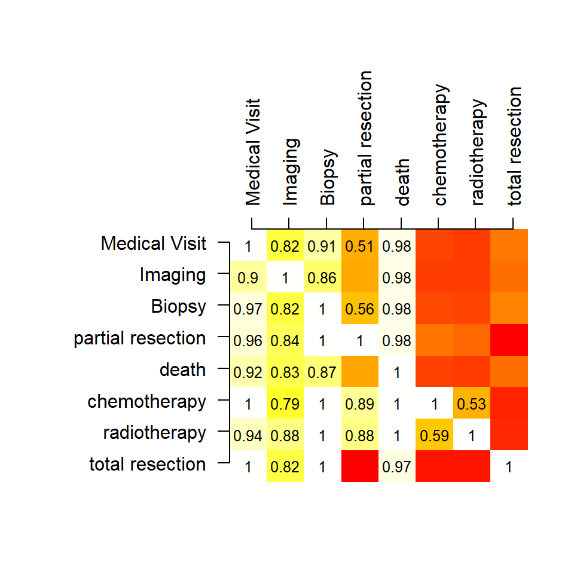

```r
objQOD$eventHeatmap(cex =0.8)
```

we can observe that in the 56% of the cases, after a *Biopsy* we have (in one or more steps) a *partial resection*. If we are intersted in focusing the attention on specific window of %, we can specify the window setting the lower of the upper bound :

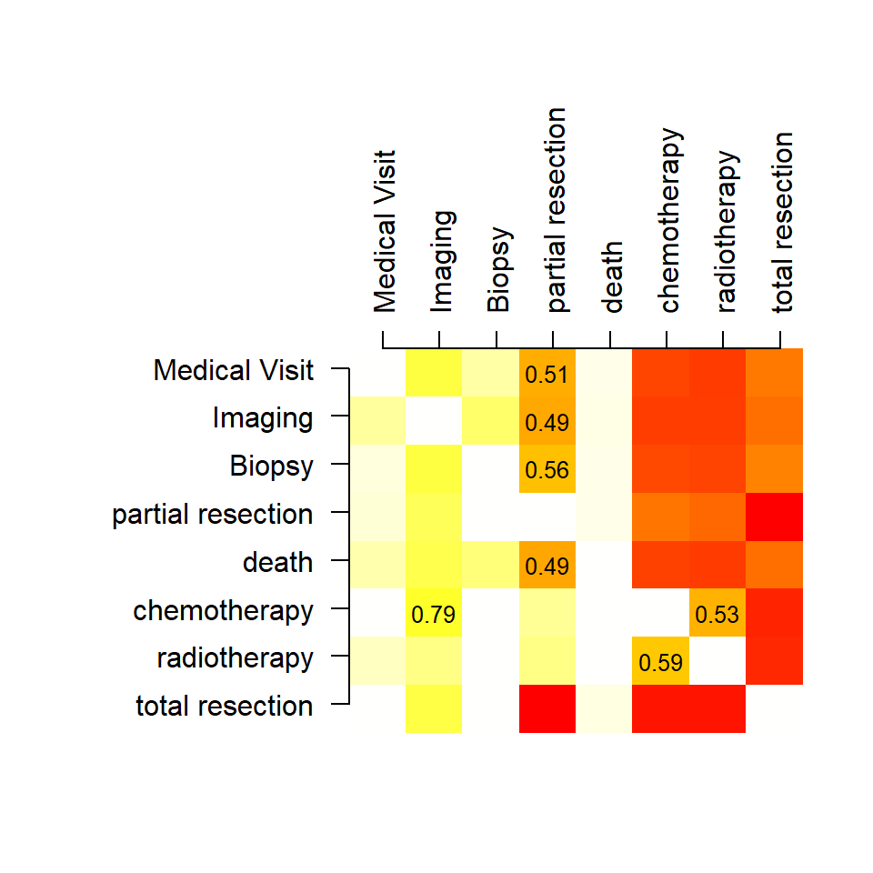

```r
objQOD$eventHeatmap(cex =0.8,threshold.low = 0.40,threshold.hi = 0.80  )
```

the parameters *cex*, *show.diagonal* and *par.margin* and meant for graphical use and specify respectively: the font size, the presence of not of numbers in the diagonal and the margins of the image.

## 1.4 Plotting a cohort of timelines

To graphically represent one or more timeline, also deciding which events should be plotted, the methods *QOD::plotTimeline()* can be used. In the following example, the entire cohort is plotted, scaling the x-axes in months, and the *death* and *Biopsy* events are plotted with a pch equal to 17 and 19 respectively:

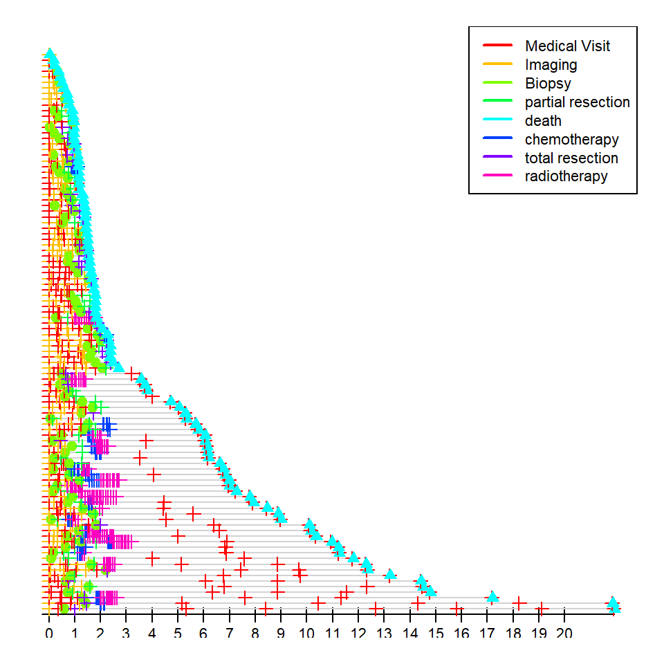

```r
objQOD$plotTimeline(objDL.obj = objDL.out,UM = "months",ID.on.y.label = FALSE,arr.evt.pch = c("Biopsy"=19,"death"=17))
```

Note: the parameter *objDL.out* is optional: if not specified, *QOD::plotTimeline()* will use the data previously loaded with the class *QOD::loadDataset()*.

We can also plot a limited set of patients, showing the IDs. In the following case we limited the plot, changed the ordering and repositioned the legend.

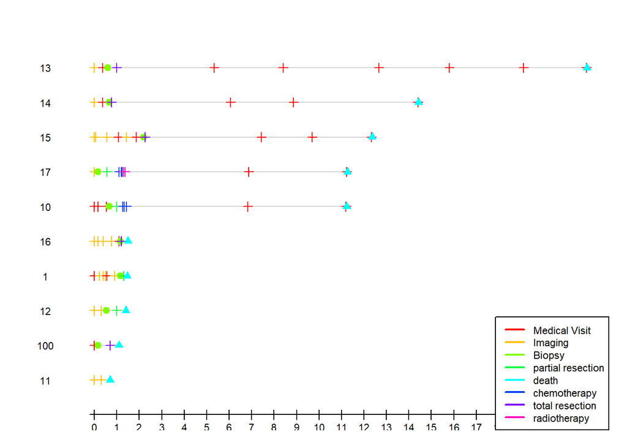

```r
arr.IPP.to.plot <- names(objDL.out$pat.process)[1:10]
objQOD$plotTimeline(objDL.obj = objDL.out,arr.ID = arr.IPP.to.plot, UM = "months",ID.on.y.label = TRUE,arr.evt.pch = c("Biopsy"=19,"death"=17),ID.ordering = TRUE,ID.ordering.desc = FALSE,legend.Pos = "bottomright")
```

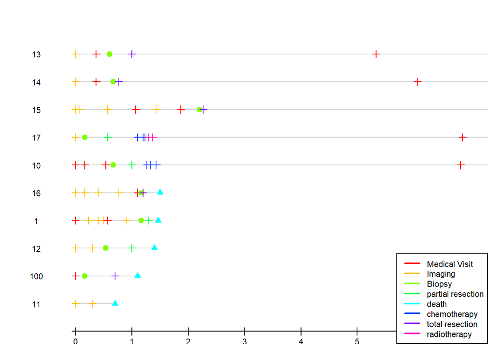

```r
arr.IPP.to.plot <- names(objDL.out$pat.process)[1:10]
objQOD$plotTimeline(objDL.obj = objDL.out,arr.ID = arr.IPP.to.plot, UM = "months",ID.on.y.label = TRUE,arr.evt.pch = c("Biopsy"=19,"death"=17),ID.ordering = TRUE,ID.ordering.desc = FALSE,legend.Pos = "bottomright",max.time = 7)
```

And to avoid a chaotic situation of markers we can also limit the dot to a subset of Events, for example *Biopsy*,*partial resection* and *death*:

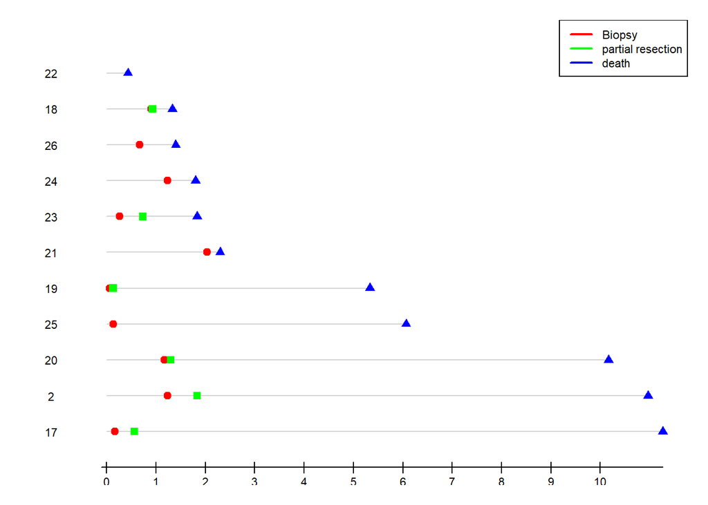

```r
arr.IPP.to.plot <- names(objDL.out$pat.process)[10:20]
objQOD$plotTimeline(objDL.obj = objDL.out, arr.events = c("Biopsy","partial resection","death"), arr.ID = arr.IPP.to.plot, UM = "months",ID.on.y.label = TRUE,arr.evt.pch = c("Biopsy"=19,"death"=17,"partial resection"=15),max.time = 14)
```

The admitted parameters are the following:

- *objDL.obj* : is the output of the method *dataLoader::getData()*. This is optional: if not specified, the method will use what previously loaded with the method *QOD:loadDataset()*.
- *arr.ID* : if specified it contains the set of Patient’s ID to plot. The default is c() and means “all”
- *max.time* : is the max time to window the x-axes.
- *UM* : the unit of measure. It cna be “minutes”, “hours”, “days”, “weeks”, “months”
- *arr.events* : is the set of events to plot. The default is c() which means "all*
- *arr.evt.pch* : by default the events are plotted with a pch equal to 3 or the one indicated in the *evt.pch.default.value* parameter. In this array the user can associate one or more event to a specific pch. The array names are the event names and the values are the wished pchs.
- *evt.pch.default.value* : is the pch which should be used by default for all the events
- *ID.on.y.label* : can be TRUE or FALSE. If set to TRUE the IDs will be plotted, for each trace, on the left
- *y.label.cex* : the cex for the y-axes
- *Time.on.x.label* : if TRUE it shows the time on the x-axes.
- *x.label.cex* : the cex for the x-axes
- *plot.legend* : it can be TRUE or FALSE and permits to plot the legend, in a desided position
- *legend.Pos* : it permits to posiiton the legend.
- *legend.cex* : the cex for the legend
- *ID.ordering* : if set to TRUE (default) permits to order the traces from the shortest to the longest or vice versa;
- *ID.ordering.desc* : if *ID.ordering* is set to TRUE, this parameter can be set to TRUE to have a descending or to FALSE for an ascending ordering of the traces.

## 1.5 Plotting the aligned traces

The method *QOD::plotTraceEvolution* permits to plot the traces, aligned, and reveal the contribute of all the traces during the time.

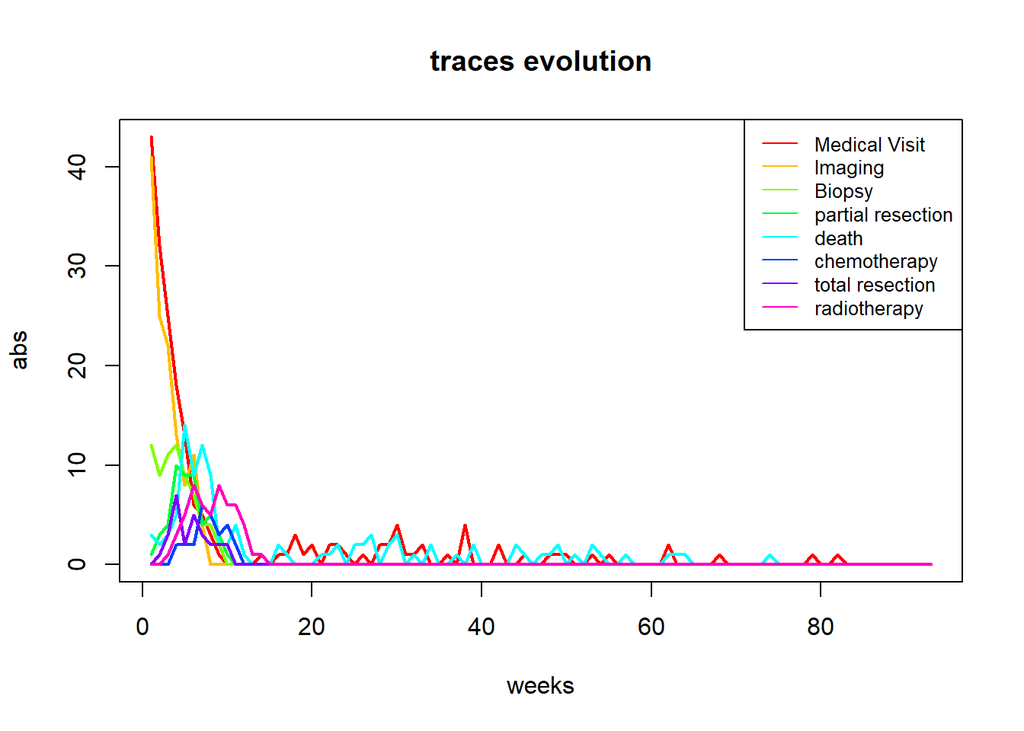

```r
objQOD$plotTraceEvolution(objDL.out = objDL.out,UM = "weeks")
```

we also might want to see the cumulative, maybe for *death* and *Biopsy* only:

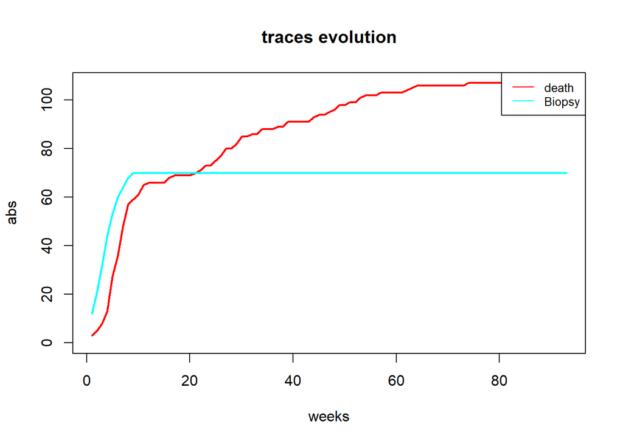

```r
objQOD$plotTraceEvolution(objDL.out = objDL.out,UM = "weeks",cumulative = TRUE,arr.events = c("death","Biopsy"))
```

In some cases, the events in the Event Log can refer to persiting events during the time. Let’s condider the following example:

| ID | Event | Date | Sex |
| --- | --- | --- | --- |
| 1 | Hospitalisation | 2001-01-04 | M |
| 1 | Home | 2001-01-11 | M |
| 1 | Hospitalisation | 2001-01-16 | M |
| 1 | Home | 2001-01-19 | M |
| 1 | death | 2001-02-17 | M |
| 2 | Hospitalisation | 2001-01-09 | M |
| 2 | Home | 2001-01-14 | M |
| 3 | Hospitalisation | 2001-01-09 | F |
| 3 | Home | 2001-01-18 | F |
| 3 | Hospitalisation | 2001-01-21 | F |
| 3 | ICU | 2001-01-31 | F |
| 3 | death | 2001-02-07 | F |
| 4 | Home | 2001-01-08 | F |
| 4 | Hospitalisation | 2001-01-22 | F |
| 4 | Home | 2001-01-23 | F |

```r
newDLobj <- dataLoader(verbose.mode = FALSE)
newDLobj$load.csv(nomeFile = "../dataS/five.generated.csv",sep = ";",IDName = "ID",EVENTName = "Event",dateColumnName = "Date",format.column.date = "%Y-%m-%d")
```

we can avoid to create a new *QOD* class by passing the *newDLobj::getData()* into the input parameter *objDL.out*, in the method *QOD::plotTraceEvolution()*:

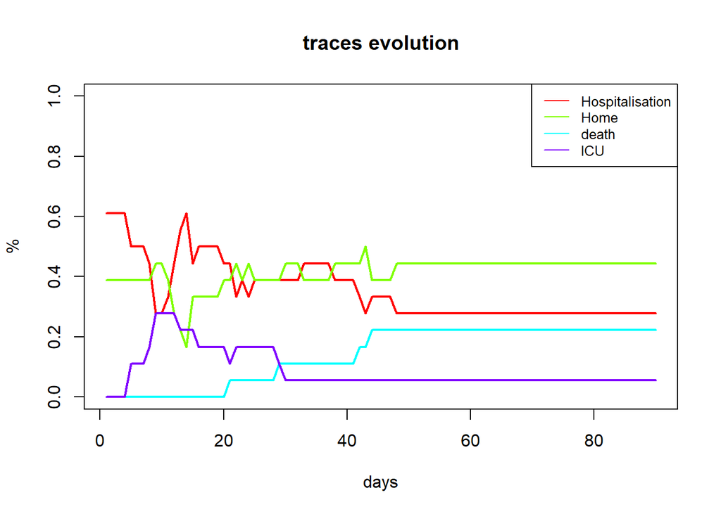

```r
objQOD$plotTraceEvolution(objDL.out = newDLobj$getData(),holdEvts = TRUE,UM = "days",max.t = 90)
```

So, the **holdEvts** set to **TRUE** propagate ahead the state of an event and allow us to consider it as a *state* that will change when the next event will happen.